# Lecture 06: Tables

Associated Textbook Sections: [3.4](https://ccsf-math-108.github.io/textbook/chapters/03/4/Introduction_to_Tables.html)

## Overview

- Tables
- Attributes and Properties
- Some Table Methods

## Set Up the Notebook

```python
from datascience import *
import numpy as np
```

## Tables

### Early Beginnings

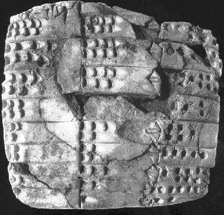

Ancient Mesopotamia (modern-day Iraq):

- Sumer, Babylonia, and Assyria had clay tablets from around 2600-1600 BCE that provide examples of some of the earliest recorded numerical tables
- The tablets demonstrate their proficiency in recording mathematical and astronomical data

The image above shows the world's oldest dateable mathematical table (on record), from the Sumerian city of Shuruppag, c. 2600 BCE. The first two columns contain identical lengths in descending order from 600 to 60 rods (c. 3600-360 m) and the final column contains the square area of their product

### Table Structure

- The `datascience` library contains a data type called a `Table`.
- A `Table` is a sequence of labeled columns
- Each row represents one individual
- Data within a column represents one attribute of the individuals

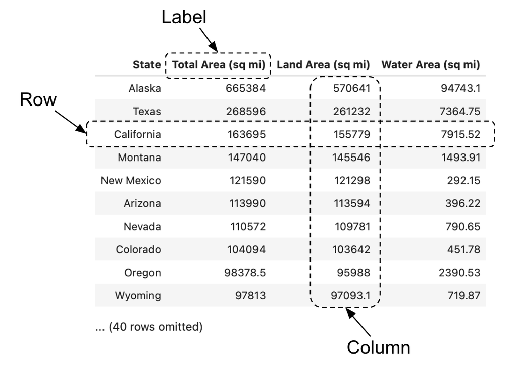

### Loading Data

- Data analysis usually includes connecting to various data sources
- We focus on loading data from CSV files
  - Comma Separated Values
  - `.csv` extension
- The `Table.read_table` function will load the contents of a CSV into the notebook as a `Table`.

### Demo: Loading Data

[figure not shown]

Import data in `states_area.csv` that contains land and water area data sourced form [Wikipedia](https://en.wikipedia.org/wiki/List_of_U.S._states_and_territories_by_area).

```python
states = Table.read_table('states_area.csv')
states
```

| State | Total Area (sq mi) | Land Area (sq mi) | Water Area (sq mi) |
| --- | --- | --- | --- |
| Alaska | 665384 | 570641 | 94743.1 |
| Texas | 268596 | 261232 | 7364.75 |
| California | 163695 | 155779 | 7915.52 |
| Montana | 147040 | 145546 | 1493.91 |
| New Mexico | 121590 | 121298 | 292.15 |
| Arizona | 113990 | 113594 | 396.22 |
| Nevada | 110572 | 109781 | 790.65 |
| Colorado | 104094 | 103642 | 451.78 |
| Oregon | 98378.5 | 95988 | 2390.53 |
| Wyoming | 97813 | 97093.1 | 719.87 |

... (40 rows omitted)

```python
type(states)
```

```
datascience.tables.Table
```

```python
a = 5
type(a)
```

```
int
```

## Attributes and Properties

A `Table` has information that we can access by command. For example:

- `t.labels` - the labels of a table called `t`
- `t.num_columns` - the number of columns in `t`
- `t.num_rows` - the number of rows in `t`
- `t.rows` - a collection of all the rows in `t`

### Demo: Attributes and Properties

There are various attributes of a table that you can access as well using the dot notation such as `labels`, `num_columns`, and `num_rows`.

```python
states.labels
```

```
('State', 'Total Area (sq mi)', 'Land Area (sq mi)', 'Water Area (sq mi)')
```

```python
states.num_columns
```

```
4
```

```python
states.num_rows
```

```
50
```

```python
states.rows
```

```
Rows(State      | Total Area (sq mi) | Land Area (sq mi) | Water Area (sq mi)
Alaska     | 665384             | 570641            | 94743.1
Texas      | 268596             | 261232            | 7364.75
California | 163695             | 155779            | 7915.52
Montana    | 147040             | 145546            | 1493.91
New Mexico | 121590             | 121298            | 292.15
Arizona    | 113990             | 113594            | 396.22
Nevada     | 110572             | 109781            | 790.65
Colorado   | 104094             | 103642            | 451.78
Oregon     | 98378.5            | 95988             | 2390.53
Wyoming    | 97813              | 97093.1           | 719.87
... (40 rows omitted))
```

```python
states.rows[15] # example to print the 15th row of the table
```

```
Row(State='Nebraska', Total Area (sq mi)=77347.809999999998, Land Area (sq mi)=76824.169999999998, Water Area (sq mi)=523.63999999999999)
```

## Some Table Methods

There is a collection of methods (functions) associated with every `Table` created. For example:

- `t.show(n)` - displays the first `n` rows of a table called `t`
- `t.select(label)` - constructs a new table with just the specified columns
- `t.drop(label)` - constructs a new table in which the specified columns are omitted
- `t.sort(label)` - constructs a new table with rows sorted by the specified column
- `t.where(label, condition)` - constructs a new table with just the rows that match the condition
  - Initially, the `condition` will be made up using Predicates such as `are.above`, `are.equal_to`, etc.
- More can be found in the [`datascience` documentation](https://datascience.readthedocs.io/en/master/tables.html)

### Demo: `show`

Explore the `show` table method.

```python
states.show(3)
```

| State | Total Area (sq mi) | Land Area (sq mi) | Water Area (sq mi) |
| --- | --- | --- | --- |
| Alaska | 665384 | 570641 | 94743.1 |
| Texas | 268596 | 261232 | 7364.75 |
| California | 163695 | 155779 | 7915.52 |

... (47 rows omitted)

```python
...
```

```python
# show(3) does not produce a Table
states_show_3 = ...
type(states_show_3)
```

### Demo: `select`

Use the `select` table method to select columns by column labels and column indexes.

```python
states.select('State', 'Total Area (sq mi)') # SOLUTION
```

| State | Total Area (sq mi) |
| --- | --- |
| Alaska | 665384 |
| Texas | 268596 |
| California | 163695 |
| Montana | 147040 |
| New Mexico | 121590 |
| Arizona | 113990 |
| Nevada | 110572 |
| Colorado | 104094 |
| Oregon | 98378.5 |
| Wyoming | 97813 |

... (40 rows omitted)

```python
y = states.select('State', 'Water Area (sq mi)') # SOLUTION
y
```

| State | Water Area (sq mi) |
| --- | --- |
| Alaska | 94743.1 |
| Texas | 7364.75 |
| California | 7915.52 |
| Montana | 1493.91 |
| New Mexico | 292.15 |
| Arizona | 396.22 |
| Nevada | 790.65 |
| Colorado | 451.78 |
| Oregon | 2390.53 |
| Wyoming | 719.87 |

... (40 rows omitted)

```python
states.select(0, 1)
```

| State | Total Area (sq mi) |
| --- | --- |
| Alaska | 665384 |
| Texas | 268596 |
| California | 163695 |
| Montana | 147040 |
| New Mexico | 121590 |
| Arizona | 113990 |
| Nevada | 110572 |
| Colorado | 104094 |
| Oregon | 98378.5 |
| Wyoming | 97813 |

... (40 rows omitted)

```python
A = 5
a = 1

print(A, a)
# 1, 1
# 5, 1
```

```
5 1
```

```python
...
```

```
Ellipsis
```

```python
# A NameError where the column name was used incorrectly.
# states.select(State, 'Total Area (sq mi)')
```

```python
# A ValueError where the column name was used incorrectly.
# states.select('State', 'Total Area')
```

### Demo: `drop`

Use the `drop` table method to drop columns by name and by index.

```python
states
```

| State | Total Area (sq mi) | Land Area (sq mi) | Water Area (sq mi) |
| --- | --- | --- | --- |
| Alaska | 665384 | 570641 | 94743.1 |
| Texas | 268596 | 261232 | 7364.75 |
| California | 163695 | 155779 | 7915.52 |
| Montana | 147040 | 145546 | 1493.91 |
| New Mexico | 121590 | 121298 | 292.15 |
| Arizona | 113990 | 113594 | 396.22 |
| Nevada | 110572 | 109781 | 790.65 |
| Colorado | 104094 | 103642 | 451.78 |
| Oregon | 98378.5 | 95988 | 2390.53 |
| Wyoming | 97813 | 97093.1 | 719.87 |

... (40 rows omitted)

```python
states.drop('Land Area (sq mi)')
```

| State | Total Area (sq mi) | Water Area (sq mi) |
| --- | --- | --- |
| Alaska | 665384 | 94743.1 |
| Texas | 268596 | 7364.75 |
| California | 163695 | 7915.52 |
| Montana | 147040 | 1493.91 |
| New Mexico | 121590 | 292.15 |
| Arizona | 113990 | 396.22 |
| Nevada | 110572 | 790.65 |
| Colorado | 104094 | 451.78 |
| Oregon | 98378.5 | 2390.53 |
| Wyoming | 97813 | 719.87 |

... (40 rows omitted)

```python
...
```

### Demo: `sort`

```python
#?states.sort
```

```python
#help(states.sort)
```

Use the `sort` table method to sort the data in the table by a certain column.

```python
states.sort('Total Area (sq mi)')
```

| State | Total Area (sq mi) | Land Area (sq mi) | Water Area (sq mi) |
| --- | --- | --- | --- |
| Rhode Island | 1544.89 | 1033.81 | 511.07 |
| Delaware | 2488.72 | 1948.54 | 540.18 |
| Connecticut | 5543.41 | 4842.36 | 701.06 |
| New Jersey | 8722.58 | 7354.22 | 1368.36 |
| New Hampshire | 9349.16 | 8952.65 | 396.51 |
| Vermont | 9616.36 | 9216.66 | 399.71 |
| Massachusetts | 10554.4 | 7800.06 | 2754.33 |
| Hawaii | 10931.7 | 6422.63 | 4509.09 |
| Maryland | 12405.9 | 9707.24 | 2698.69 |
| West Virginia | 24230 | 24038.2 | 191.83 |

... (40 rows omitted)

```python
states.sort('Total Area (sq mi)', descending=False)#.show(3)
```

| State | Total Area (sq mi) | Land Area (sq mi) | Water Area (sq mi) |
| --- | --- | --- | --- |
| Rhode Island | 1544.89 | 1033.81 | 511.07 |
| Delaware | 2488.72 | 1948.54 | 540.18 |
| Connecticut | 5543.41 | 4842.36 | 701.06 |
| New Jersey | 8722.58 | 7354.22 | 1368.36 |
| New Hampshire | 9349.16 | 8952.65 | 396.51 |
| Vermont | 9616.36 | 9216.66 | 399.71 |
| Massachusetts | 10554.4 | 7800.06 | 2754.33 |
| Hawaii | 10931.7 | 6422.63 | 4509.09 |
| Maryland | 12405.9 | 9707.24 | 2698.69 |
| West Virginia | 24230 | 24038.2 | 191.83 |

... (40 rows omitted)

```python
states.sort('Total Area (sq mi)', descending=True).show(3)
```

| State | Total Area (sq mi) | Land Area (sq mi) | Water Area (sq mi) |
| --- | --- | --- | --- |
| Alaska | 665384 | 570641 | 94743.1 |
| Texas | 268596 | 261232 | 7364.75 |
| California | 163695 | 155779 | 7915.52 |

... (47 rows omitted)

```python
...
```

```python
...
```

```python
...
```

### Demo: `where`

Use the `where` table method to filter the data in the table.

```python
# Nothing Filtered
...
```

```python
states.where('State', are.equal_to('California')) # SOLUTION
```

| State | Total Area (sq mi) | Land Area (sq mi) | Water Area (sq mi) |
| --- | --- | --- | --- |
| California | 163695 | 155779 | 7915.52 |

```python
#states[states.column('Land Area (sq mi)') >  100000]
```

```python
states.where('Land Area (sq mi)', are.above(100_000)) # SOLUTION
```

| State | Total Area (sq mi) | Land Area (sq mi) | Water Area (sq mi) |
| --- | --- | --- | --- |
| Alaska | 665384 | 570641 | 94743.1 |
| Texas | 268596 | 261232 | 7364.75 |
| California | 163695 | 155779 | 7915.52 |
| Montana | 147040 | 145546 | 1493.91 |
| New Mexico | 121590 | 121298 | 292.15 |
| Arizona | 113990 | 113594 | 396.22 |
| Nevada | 110572 | 109781 | 790.65 |
| Colorado | 104094 | 103642 | 451.78 |

```python
states.where('State', are.containing('New')) # SOLUTION
```

| State | Total Area (sq mi) | Land Area (sq mi) | Water Area (sq mi) |
| --- | --- | --- | --- |
| New Mexico | 121590 | 121298 | 292.15 |
| New York | 54555 | 47126.4 | 7428.58 |
| New Hampshire | 9349.16 | 8952.65 | 396.51 |
| New Jersey | 8722.58 | 7354.22 | 1368.36 |

```python
import pandas as pd
x = pd.DataFrame([[1, 2, 3], [4,5,6]]).T
x.columns=['A', 'B']
x
```

|  | A | B |
| --- | --- | --- |
| 0 | 1 | 4 |
| 1 | 2 | 5 |
| 2 | 3 | 6 |

```python
x[x['A'] > 1]
```

[output not shown]

```python
x[(x['A'] > 1) & (x['B'] < 6)]
```

|  | A | B |
| --- | --- | --- |
| 1 | 2 | 5 |

## Attribution

This content is licensed under the Creative Commons Attribution-NonCommercial-ShareAlike 4.0 International License (CC BY-NC-SA 4.0) and derived from the Data 8: The Foundations of Data Science offered by the University of California, Berkeley.